# Create Quantiles/Declines Plot

This notebook will create a quantiles plot.

The aim of this plot is to ‘see’ how quickly adjuvant abemaciclib is adopted. Abemaciclib is the only CDK4/6 inhibitor that is used in the adjuvant setting and was funded through the Cancer Drugs Fund on 17th June 2022. We can therefore assume all use prior to June was not adjuvant, and as the use was fairly steady see the change in use from June as *likely* to be adjuvant use.

The three key dates are 17th June (CDF Funding), 20 July 2022 (NICE formal approval), and 90 days later - when implementation of NICE guidance is mandated.

## Load the data

```r
# load some required packages for data carpentry and visualisation
require(dplyr)
require(tidyr)

# Get the dataset
# Requires cleaned data
cdk46Data <- readRDS(here::here("data/cdk46_op_hosp_clean.RDS"))

# agregate the data to VTM & month & trust
cdk46Data |>
  # exclude dates in 2025
  filter(year_month < as.Date("2025-01-01")) |>
  # get the VTM (ingredient)
  separate_wider_delim(vmp_name, delim=" ", names = c("VTM", "strength", "form")) |>
  # remove anything that isn't abema
  filter(VTM == "Abemaciclib") |>
  # summarise the data using month and organisation
  group_by(year_month, VTM, new_code ) |>
  # As not comparing across drugs - can simply use quantity rather than dose
  summarise(qty=sum(quantity)) -> abemaData
head(abemaData)
```

| year_month | VTM | new_code | qty |
| --- | --- | --- | --- |
| 2019-04-01 | Abemaciclib | R1F | 56 |
| 2019-04-01 | Abemaciclib | RA2 | 336 |
| 2019-04-01 | Abemaciclib | RA7 | 168 |
| 2019-04-01 | Abemaciclib | RAL | 56 |
| 2019-04-01 | Abemaciclib | RAP | 196 |
| 2019-04-01 | Abemaciclib | RBV | 1512 |

## Plot the median use monthly

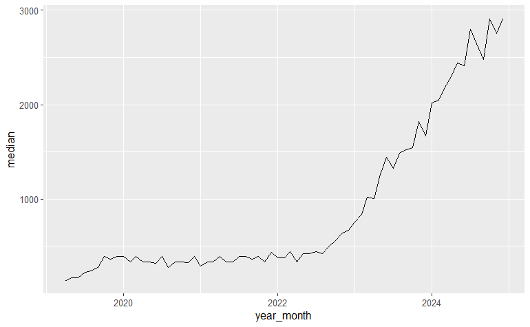

```r
abemaData |>
  group_by(year_month) |>
  summarise(median = median(qty)) |>
  ggplot(aes(x = year_month, y=median)) +
  geom_line()
```

If we plot a line for every trust -

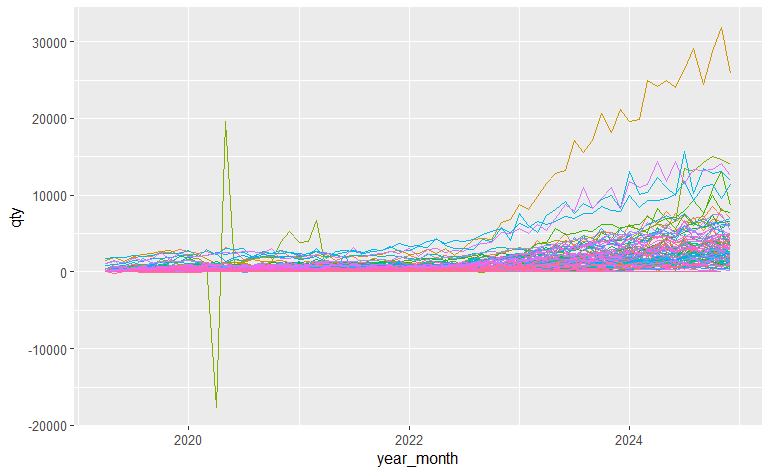

```r
abemaData |>
  group_by(year_month) |>
  ggplot(aes(x = year_month, y=qty, colour=new_code)) +
  geom_line() +
  theme(legend.position =  "none")
```

The data is far less interpretable, as different trusts will have different numbers of patients. We need to normalise the data somehow.

### Normalise by 12 month use prior to adjuvant

One option is to normalise trust data after adjuvant in comparison to their use prior to adjuvant. But some trusts may not have ANY use prior to adjuvant:

```r
abemaData |>
  #remove data more than a year before adjuvant
  filter(year_month >= as.Date("2021-06-01")) |>
  #allocate months to 'baseline' or 'post' change
  mutate(baseline = if_else(year_month < as.Date("2022-06-01"), "baseline", "post")) |>
  #calculate baseline and post change use by organisation
  group_by(new_code, baseline) |>
  summarise(qty=sum(qty)) |>
  #make that wide format (i.e. baseline and post change side by side)
  pivot_wider(id_cols = new_code, names_from = baseline, values_from = qty) |>
  # sort by baseline use
  ungroup()|>
  arrange(baseline) -> abemaChange
abemaChange
```

| new_code | baseline | post |
| --- | --- | --- |
| RGP | 56 | 14204 |
| RP5 | 56 | 258 |
| RW1 | 56 | 4591 |
| RTF | 112 | 37296 |
| RCX | 336 | 13216 |
| RGN | 728 | 58997 |
| RN7 | 784 | 16240 |
| RTR | 784 | 24052 |
| RFR | 784 | 15218 |
| RF4 | 952 | 29764 |

[output cut: 96 more lines]

There are some organisations with very low use prior to the adjuvant license. If we normalise using those low uses this may not be helpful. 6 trusts have no baseline activity and couldn’t be normalised. One of those trusts is a provider of mental health services; and so their data may be irrelevant.

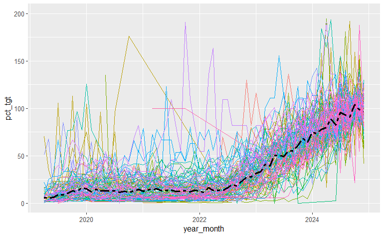

```r
abemaData |>
  filter (year_month >= as.Date("2024-10-01")) |>
  group_by(new_code) |>
  summarise(target = mean(qty, na.rm = T)) -> targets

abemaData |>
  left_join(targets) |>
  mutate(pct_tgt = 100*(qty/target)) |>
  group_by(year_month) -> abemaData_with_targets
# Calculate monthly medians
abemaData_with_targets |>
  group_by(year_month) |>
  summarise(median = median(pct_tgt, na.rm=T)) -> abema_median_targets


abemaData_with_targets |>
  ggplot(aes(x = year_month, y=pct_tgt, colour=new_code)) +
  geom_line() +
  theme(legend.position =  "none") +
  ylim(0,200) + # values > 200 percent are likely spurious
  # add a dotted heavy line for the median
  geom_line(lwd=1.1, colour = "black", lty = 6, aes(y=median, x = year_month), data = abema_median_targets)
```

While this curve is obviously very difficult to read for an individual trust, it shows the range and variability of the data. We can rebuild this showing quartile and decile ranges. We can also exclude data prior to 2021 as it is not important for the comparison

## Display Quartiles and Deciles

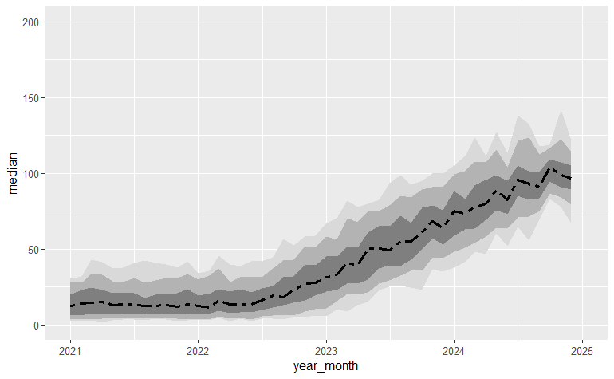

```r
abemaData_with_targets |>
  group_by(year_month) |>
  summarise(median = quantile(pct_tgt, probs = 0.5, na.rm=T),
            pct_75 = quantile(pct_tgt, probs = 0.75, na.rm=T),
            pct_90 = quantile(pct_tgt, probs = 0.9, na.rm=T),
            pct_95 = quantile(pct_tgt, probs = 0.95, na.rm=T),
            pct_25 = quantile(pct_tgt, probs = 0.25, na.rm=T),
            pct_10 = quantile(pct_tgt, probs = 0.1, na.rm=T),
            pct_05 = quantile(pct_tgt, probs = 0.05, na.rm=T)
            ) -> abema_quartile_targets

abemaData_with_targets |>
  ungroup() |>
  ggplot() +
 # geom_line() +
  theme(legend.position =  "none") +
  ylim(0,200) + # values > 200 percent are likely spurious
  xlim(as.Date("2021-01-01"), "2024-12-31") +
  # Layer the quantiles from widest to narrowest
  # add 5-95% quantile
  geom_ribbon(aes(ymin = pct_05, ymax = pct_95, x = year_month ), fill = "grey85",  data = abema_quartile_targets) +
  # add 10-90% quantile
  geom_ribbon(aes(ymin = pct_10, ymax = pct_90, x = year_month ), fill = "grey70", stat="identity", data = abema_quartile_targets) +
  # add 25-75% quantile
  geom_ribbon(aes(ymin = pct_25, ymax = pct_75, x = year_month ), fill = "grey50", stat="identity", data = abema_quartile_targets) +
  # add a dotted heavy line for the median
  geom_line(lwd=1.1, colour = "black", lty = 6, aes(y=median, x = year_month), data = abema_quartile_targets) -> quantilePlot

print(quantilePlot)
```

```r
NA
```

### Format the plot

This plot is starting to look usable, so we will add some improved formatting (titles, axis labels, background panel etc)

```r
quantilePlot+
  theme_classic() +
  ggsci::scale_color_jama() +
  theme(panel.grid.major.y = element_line(linewidth = 0.5)) +
  ylim(0,150) +
  ylab("Percentage of abemaciclib use in final quarter of 2024") +
  xlab("Month") +
  ggtitle("Quantile ranges of issues of abemaciclib by individual NHS Trusts",
          subtitle = "as a percentage of the trust's use in Q4 2024") -> quantilePlot
```

### Annotate the plot

It would be useful to annotate the plot with key timeline events (CDF fuding, NICE possitive appriasal and 90 day time limit)

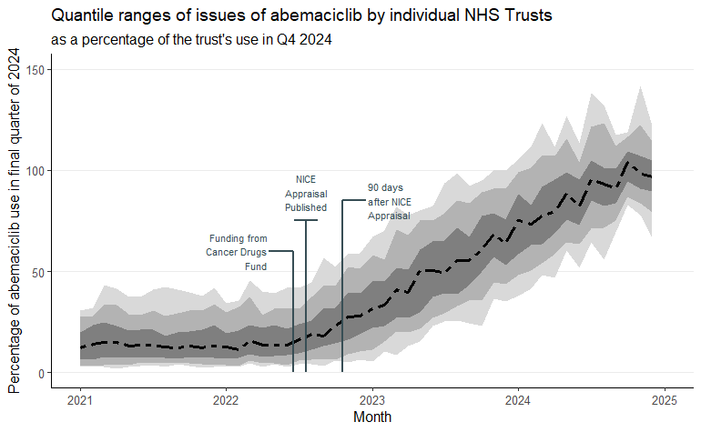

```r
# Build a simple dataset for the annotations

tibble(
  year_month = as.Date(c("2022-06-17", "2022-07-20", "2022-10-18")),
  marker = c(60, 75, 85),
  label = c("Funding from Cancer Drugs Fund", "NICE Appraisal Published", "90 days after NICE Appraisal"),
  position = c("left", "above", "right")
) -> events

quantilePlot +
  # add vertical markers for annotations
  geom_segment(data=events,
               aes(x=year_month, xend=year_month, y = 0, yend= marker, colour = "a"),
               lwd=0.8, lty=1) +
  # plot all the left horizontal marker lines
  geom_segment(data=filter(events, position == "left"),
               aes(x=year_month, xend=year_month-60, y = marker, yend= marker, colour="a"),
               lwd=0.8, lty=1) +
# plot all the right horizontal marker lines
  geom_segment(data=filter(events, position == "right"),
               aes(x=year_month, xend=year_month+60, y = marker, yend= marker, colour="a"),
               lwd=0.8, lty=1) +
# plot all the top horizontal marker lines
  geom_segment(data=filter(events, position == "above"),
               aes(x=year_month-30, xend=year_month+30, y = marker, yend= marker, colour="a"),
               lwd=0.8, lty=1) +
# plot all the left text
  geom_text(data=filter(events, position == "left"),
               aes(x=year_month - 65, y = marker, colour="a",
                   label = stringr::str_wrap(label, 12)),
            size = 2.7, hjust = 1) +
# plot all the right text
  geom_text(data=filter(events, position == "right"),
               aes(x=year_month + 65, y = marker, colour="a",
                   label = stringr::str_wrap(label, 12)),
            size = 2.7, hjust = 0) +
# plot all the above text
  geom_text(data=filter(events, position == "above"),
               aes(x=year_month, y = marker+5, colour="a",
                   label = stringr::str_wrap(label, 12)),
            size = 2.7, hjust = 0.5, vjust = 0) +
  theme(legend.position = "none") -> quantilePlot

print(quantilePlot)
```

[figure not shown]

```r
print(quantilePlot)
```

We can then add some ‘interesting’ trusts to the plot

[figure not shown]

```r
quantilePlot +
  geom_line(data = abemaData_with_targets[abemaData_with_targets$new_code == "RCB",],
            aes(x=year_month, y=pct_tgt, colour =  "C"), lwd=0.8) +
  geom_text(aes(x=as.Date("2023-08-01"), y=30, label = "York & Scarborough TH NHS FT", colour = "C"), size=2.8, hjust=0) +
    geom_line(data = abemaData_with_targets[abemaData_with_targets$new_code == "RXP",],
            aes(x=year_month, y=pct_tgt, colour =  "D"), lwd=0.8) +
  geom_text(aes(x=as.Date("2023-12-01"), y=100, label = "County Durham & Darlington NHS FT", colour = "D"), size=2.8, hjust=1)
```